# Homework 8

# Getting Started

The data for this homework comes from the [Open University Learning Analytics Dataset (OULAD)](https://analyse.kmi.open.ac.uk/open_dataset). It contains data about courses, students, and their interactions with Virtual Learning Environment (VLE) for seven selected courses (called modules). Presentations of courses start in February and October - they are marked by “B” and “J” respectively. The dataset (tables) are connected using unique identifiers. All datasets are stored in the .csv format. Please check out the [OULAD](https://analyse.kmi.open.ac.uk/open_dataset) site to learn more about the data and understand the keys.

### 1. Start a new RStudio Project

#### 1.1. Be sure to add a folder for “data” and “scripts”.

### 2. Data

#### 2.1. Download the *studentInfo.csv*, *studentAssessment.csv*, and *assessments.csv* data from the course website.

#### 2.2. Place the files in the “data” folder in your project.

#### 2.3. Read in the data.

### 3. Join

#### 3.1. Join the *studentassessment* data and the *assessments* data. Specify to join by `id_assessment` and `date`. *Note* that the `date` column has a different name in *studentassessment* (`date_submitted`). Name the joined data *assess_full*. Filter *assess_full* to remove `NA` values in the `code_module` column.

#### 3.2. Join the *studentinfo* data to the newly created *assess_full* data. Name the joined data *student*.

#### 3.3. What key(s) were used in the join?

id_student, code_module, code_presentation

#### 3.4. How many rows are in the newly created *student* data? If that is different than the number of rows in the *studentInfo* data, why?

There are 32593 rows in studentInfo and only 29469 rows in student because we removed rows with missing values in the `code_module` variable.

#### 3.5. What new variables were added with this join?

gender, region, highest_education, imd_band, age_band, num_of_prev_attempts, studied_credits, disability, final_result

### 4. Wrangle

#### 4.1. From the *student* data, create a new dataset named *student_tma* that consists only of TMA (Tutor Marked Assessment) assessments.

#### 4.2. Create a new dataset named *student_tma_max*. First, remove `NA` values in the `score` column. Then keep only the maximum (`max()`) TMA score for each student (**note:** Use `mutate()` and `filter()` so that all columns are retained)

#### 4.3. How many rows are in this filtered data? What does each row represent?

Each of the 13309 rows represents a student.

#### 4.4. From *student_tma_max*, reate a dataset named *agg_tma_max* that contains the mean TMA `score` by `highest_education`, `disability`, and `final_result.`

### 5. Plot

#### 5.1. Reproduce the following plot, using any theme and colors you want *except* for the defaults.

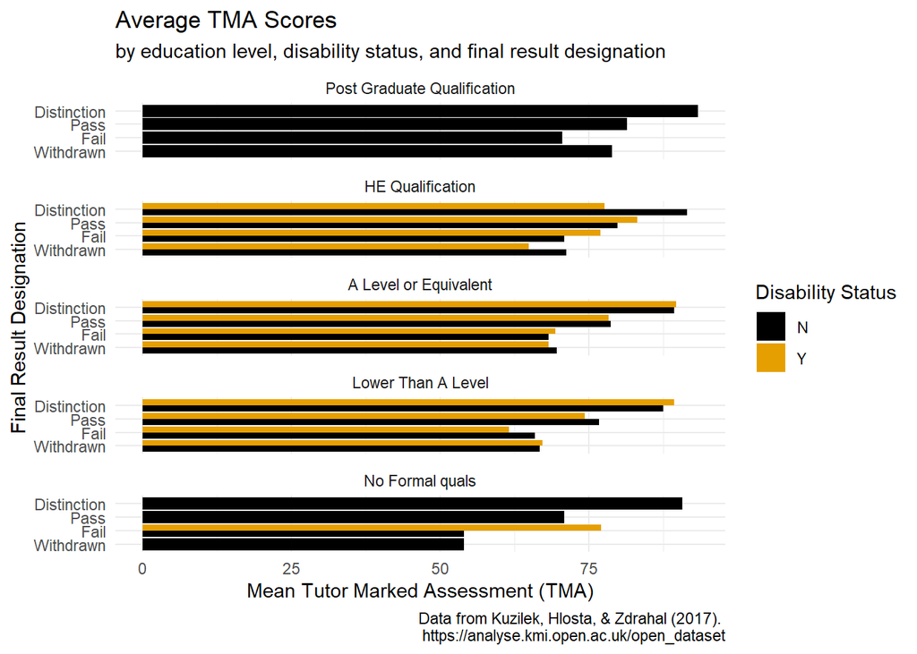